# HW2

```python
import numpy as np
import matplotlib
import matplotlib.pyplot as plt
import math as math
import scipy
from scipy import stats
```

#### 1.Which is more probable when rolling 2 six-sided dice: rolling snake eyes (two ones) or rolling sevens (dice sum to seven)? What is the ratio of the probabilities?

##### Rolling sevens is more probable

#### 2.Following what we did in class show how to use the convolution operator to determine the probability of the sum of 2 six sided dice. Do both analytically (math & counting) and numerically (computer program). Beware the implicit definition of the values (x-axis on histogram).

##### Sum of 2 six sided dice

##### Analytical Method:

##### For sum of [2,3,4,5,6,7,8,9,10,11,12],

##### Probablity=[1/36, 2/36, 3/36, 4/36, 5/36, 6/36, 5/36, 4/36, 3/36, 2/36, 1/36]

##### which is [0.028, 0.056,0.083, 0.111, 0.139,0.167,0.139,0.111,0.083, 0.056, 0.028]

##### Numerical Method:

```
[0.028 0.056 0.083 0.111 0.139 0.167 0.139 0.111 0.083 0.056 0.028]
```

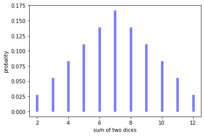

```python
d=np.linspace(2,12,11)
a=[1/6,1/6,1/6,1/6,1/6,1/6]
p=np.convolve (a,a)
np.set_printoptions(precision=3)
print(p)
plt.xlabel("sum of two dices")
plt.ylabel("probality")

plt.vlines(d, 0, p, colors='b', lw=5, alpha=0.5)
```

#### 3.Calculate the mean and the variance of the distribution in problem 2. Hint: this is surprisingly tricky, make sure your result makes sense.

```python
mean = np.average(d, weights=p)
print(f'mean is {mean:.0f}')

var = sum((d-mean)**2*p)

print(f'variance is {var:.2f}')
```

```
mean is 7
variance is 5.83
```

#### 4. Repeat 2, and graph the average of 10 dice. Is this is a Gaussian distribution? Explain in depth.

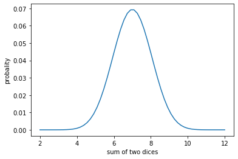

```python
count=0
p=[1/6,1/6,1/6,1/6,1/6,1/6]
v=[1/6,1/6,1/6,1/6,1/6,1/6]
for i in range(10):
    p=np.convolve (p,v)
    count+=1

x = np.linspace(2,12,56)

plt.xlabel("sum of two dices")
plt.ylabel("probality")
plt.plot(x,p)
```

##### This has to do with central limit theorem, which states that if the random sample size is big, then the distribution will approach Gaussian.

#### 5. Show that the sum and average of an initially Gaussian distribution is also a Guassian (can be analytic or numerical). How does the standard deviation of the resulting sum or average Guassian change? This is a hugely important result. Explore what this means for integrating a signal over time.

##### Sum of Gaussian distribution

##### Use Guassian distribution from previous problem

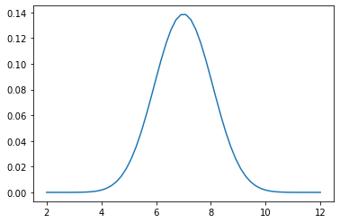

```python
sg=[]
for i in range(len(p)):
    sg.append(p[i]+p[i])

x = np.linspace(2,12,56)

plt.plot(x,sg)
```

##### The plot above still looks like a Gaussian distribution. The sum of Gaussian is still a Gaussian.

##### Average of Gaussian distrbution

##### Use the same example

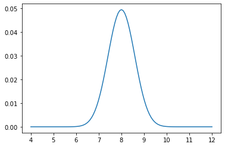

```python
sg=np.convolve (p,p)
x = np.linspace(4,12,111)
plt.plot(x,sg)
```

##### The plot above still looks like a Gaussian distribution. The average of Gaussian is still a Gaussian.

##### The standard deviation of the resulting average Guassian is smaller than the sum Gaussian.

##### This means as we integrating signal over time, or in other words as more data are collected and averaged, the distribution will get narrower and more precise.

```python
!jupyter nbconvert --to html HW2.ipynb
```

```
[NbConvertApp] Converting notebook HW2.ipynb to html
[NbConvertApp] Writing 348477 bytes to HW2.html
```